# Trump Twitter Analysis

Author

Group 14-Quan Hoang, Mailys Guedon, Joel Peterson, Li Pu

# Summary

# Introduction

Twitter (also known as X) is one of the world’s most popular social media platforms, where users can share short messages (texts, videos, photos) known as tweets. In April 2025, the Pew Research Center did a study and found that on average active users published 157 tweets per month, which is around 5 tweets per day (Gottfried and Park 2025). At the beginning of his first presidency, Donald Trump followed the average, posting about 5.7 times per day. However, towards the second half of 2020, his posting rate grew to around 34.8 times per day. On June 5 2020, he went as far as tweeting or retweeting 200 messages in a single day (McCarthy and Richter 2021). With so much data, we thought it would be interesting to consider what could affect his frequency of posting. The president uses the platform mostly to disparage those he perceives as threats (people, companies, countries…), with more than half of his tweets between January 2017 and October 2019 being used to attack something or someone (Shear et al. 2019). Another interesting question to consider would be to determine how many of his tweets can be considered as positive or negative, and to see which words come up more often for each category. In this report, we will start by considering different factors (time of day or season) that might have an impact on the frequency of the tweets, then we will classify the tweets into positive, negative or neutral to determine the most used words in the positive and negative tweets.

The dataset we are using contains all tweets published (includes deleted tweets) published by Donald Trump during his first presidency between 20 Jan 2017 and 08 Jan 2021. It contains 5 columns (ID, Time, Tweet URL, Tweet Text) and each row represents a tweet. The dataset can be found in this repository [CompleteTrumpTweetsArchive](https://github.com/MarkHershey/CompleteTrumpTweetsArchive?tab=readme-ov-file), in the data folder, specifically the file realDonaldTrump_in_office.csv.

# Method

## Analysis

In the first part, we will be doing a visual analysis on the variation in tweet posting frequency between different times of day (daytime, evening, overnight), then between different seasons (winter, summer, autumn, spring). In the second part, we will use the VADER lexicon to classify the tweets into either positive, neutral or negative categories. With the tweets now classified into positive and negative (we will consider neutral tweets as positive), we will use a bag of words approach on the tweets (CountVectorizer) to train a logistic model. We will then extract the coefficients from the model to determine the top positive and negative words.

# Results

## Part I: Does the time of day or season affect the frequency of the tweets?

The initial data filtering by time of day shows that the highest frequency of tweets occurs during the evening period between 4:01pm – 12:00am (as mentioned above) with a total of 9592 analyzed tweets. The second most frequent tweet period occurred during the overnight period between 12:01am – 8:00am with a total of 8058 analyzed tweets, with the time of day resulting in the least frequent amount of tweets actually being the daytime period between 8:01am – 4:00pm with a total of 5415 analyzed tweets. Perhaps this is because Trump is most busy during the day (golfing?) and cannot tend to tweets.

Table 1: Number of tweets published by time of day (daytime: 8:01am–4:00pm, evening: 4:01pm–12:00am, overnight: 12:01am–8:00am).

| Time of Day | Time Range | Count | Percentage |
| --- | --- | --- | --- |
| evening | 4:01pm – 12:00am | 9592 | 41.6 |
| overnight | 12:01am – 8:00am | 8058 | 34.9 |
| daytime | 8:01am – 4:00pm | 5415 | 23.5 |

The seasonal filtering of the tweets returned the results of the most frequent amount of tweets being in the Summer with 6744 analyzed tweets, with the Autumn being the second busiest season for tweets resulting in 6395 analysed tweets, followed by the Spring recording 5543 analyzed tweets, and lastly the Winter being the least busy season for tweets recording a number of 4383 tweets. This falls inline with inutitive assumptions about mood and activity as the summer is usually the busiest with longer days (daylight) and nicer weather, then the fall slowly tapers off into the winter season being the shortest days for daylight and the most restricting weather.

Table 2: Number of tweets published by season (Spring: Apr 1–Jun 30, Summer: Jul 1–Sep 30, Autumn: Oct 1–Dec 31, Winter: Jan 1–Mar 31).

| Season | Date Range | Count | Percentage |
| --- | --- | --- | --- |
| Summer | Jul 1 – Sep 30 | 6744 | 29.2 |
| Autumn | Oct 1 – Dec 31 | 6395 | 27.7 |
| Spring | Apr 1 – Jun 30 | 5543 | 24 |
| Winter | Jan 1 – Mar 31 | 4383 | 19 |

Hence, we can see that time of day and season do affect the number of tweets posted, with the theoretical most prolific time period for posting being in Summer during the evening.

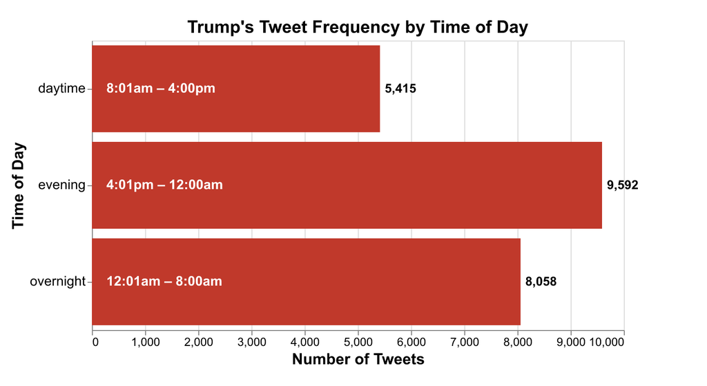

Figure 1: Trump’s Tweet Frequency by Time of Day

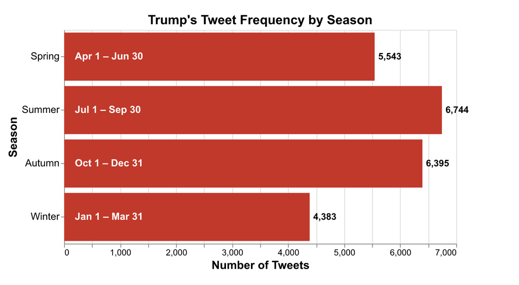

Figure 2: Trump’s Tweet Frequency by Season

Now visually comparing the two, we see that time of day has a higher impact on the frequency than season does. Indeed, there is a 77.14% increase in the number of tweets published from the daytime to the evening, while changing the season from Winter to Summer only results in a 53.87% increase.

## Part II: How many tweets are positive vs negative?

When we think of the tweets posted by the president, we tend to think mostly of those where he critices or attacks others. However, is this a real representation of the sentiments of his tweets? In this part we will begin by classify the tweets into positive, negative or neutral, then we will use those labels to analyse the words in the tweets for the positive and negative classes.

### Classifying the tweets

We use a simple sentiment analysis model (VADER) to classify each tweet as positive, negative, or neutral, and then compare the counts, this methodological inspiration is from ChatGPT.

Table 3: Number of tweets per sentiment (negative, neutral, positive).

| Sentiment | Count |
| --- | --- |
| positive | 11830 |
| neutral | 4402 |
| negative | 6833 |

Using the VADER sentiment analyzer the tweets were classified as either positive, neutral, or negative. At first, we believed that the tweets were likely more negative than positive, but in fact the tweets were classified as far more positive than negative, with the positive class representing 51.29% of the total tweets. On the other hand, the negative class only represent 29.62% of the total number of tweets, with the number of ‘neutral’ tweets close behind with 19.09%.

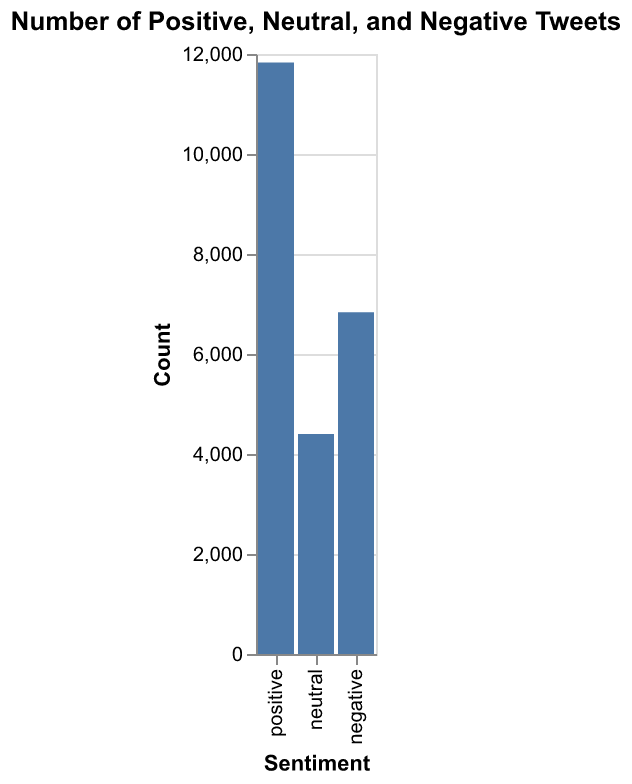

Figure 3: Number of tweets per sentiment (positive, neutral, negative).

The actual context and literal meaning of the tweets was not analyzed, nor the accuracy of the classification at this point, so there is certainly going to be a margin of error and some ‘false positives’ etc as the positivity is quite often a self directed compliment of sorts.

### Analysing the words in each tweet

Using a CountVectorizer and Logistic Regression, combining with a Wordcloud visualization to determine the most frequent words in the positive and negative tweets. Syntax and bug fixing credited to ChatGPT 5.1

The second classifier method used to analyze the tweets was utilizing the CountVectorizer() to classify sets as positive words, negative words and some stop words unique to this dataset. The overall positive VS negative tweet counts are skewed in the opposite direction as the ‘neutral’ category here is somewhat added to the postively classified category.

Table 4: Accuracy of the model

| accuracy | model_type | n_features |
| --- | --- | --- |
| 0.998191 | LogisticRegression | 4411 |

While the model achieves a high accuracy score, it might not be a true reflection of how it would perform in the ‘real’ world. Indeed, this model does not consider intricacies of language (sarcasm, neutral tweets added to positive class) that can change the sentiment of the message.

The results of the most frequent words are not very surprising to anyone who has followed American news at all in the last 10 years with the positive tweets containing words of praise (thank,good) and common phrases used by Trump (great).

Table 5: Most frequent words in positive tweets

| word | coefficient |
| --- | --- |
| thank | 4.32663 |
| great | 4.26863 |
| good | 3.79084 |
| win | 3.7133 |

The most frequent words appearing in the negative tweets could also be somewhat assumed as they words he commonly uses to criticize the opposing political parties and leaders (border, corrupt) as well as other common phrases and words that one would hear often in a news report of Trump lashing out over twitter or a speech (news, fake) .

Table 6: Most frequent words in negative tweets

| word | coefficient |
| --- | --- |
| news | 4.12918 |
| bad | 3.65169 |
| border | 3.45878 |
| fake | 3.39857 |
| crime | 3.37224 |
| terrible | 3.04244 |
| illegal | 2.96923 |
| corrupt | 2.96601 |

A great visual indicator of these word frequencies is the word clouds for the respective most frequent positive and negatively classified words. Here we can see that the words in each class make sense (it makes sense that words like bad or corrupt would be used in negative tweets while words like strong or best would be used in positive tweets).

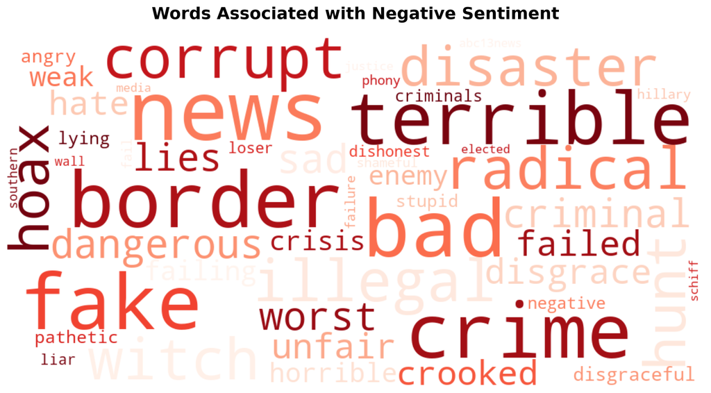

Figure 4: Word cloud of negative tweets

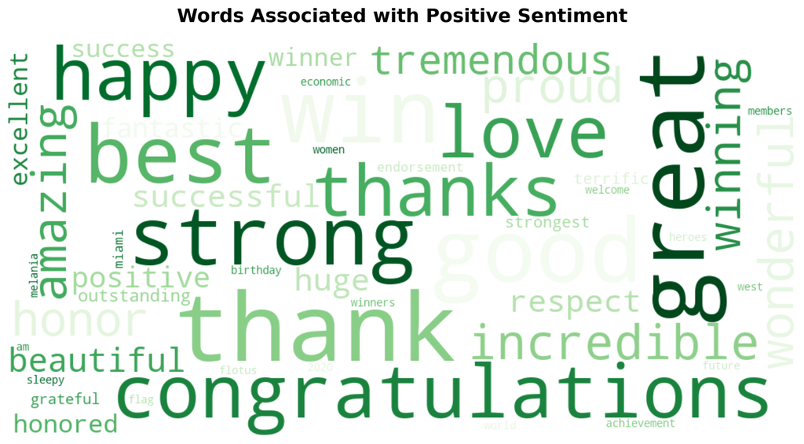

Figure 5: Word cloud of positive tweets

However, it is interesting that news is the most negative word since in itself it is neither positively or negatively connotated, but it is well known that Donald Trump considers news as fake and not to be trusted.

## Data validation

```
LogisticRegression(max_iter=2000)
```

#### Target/response variable follows expected distribution validation

For this question, since the dataset we used did not have a “target” column, we had to try using different methods in order to find the “sentiment” of the tweets this has been discussed with Instructor Sky Sheng and she gave us the go ahead. As the graphs/values of the check for usiing CountVectorizer and Logistic Regression below suggest, we do see a skewness towards positive tweets, which can be surprising to many people. This is partly due to neutral tweets are lumped together with positive tweets. However, since this dataset is about Trump’s tweets while he was in office, those tweets could be positive because he was the “powerful man” back then.

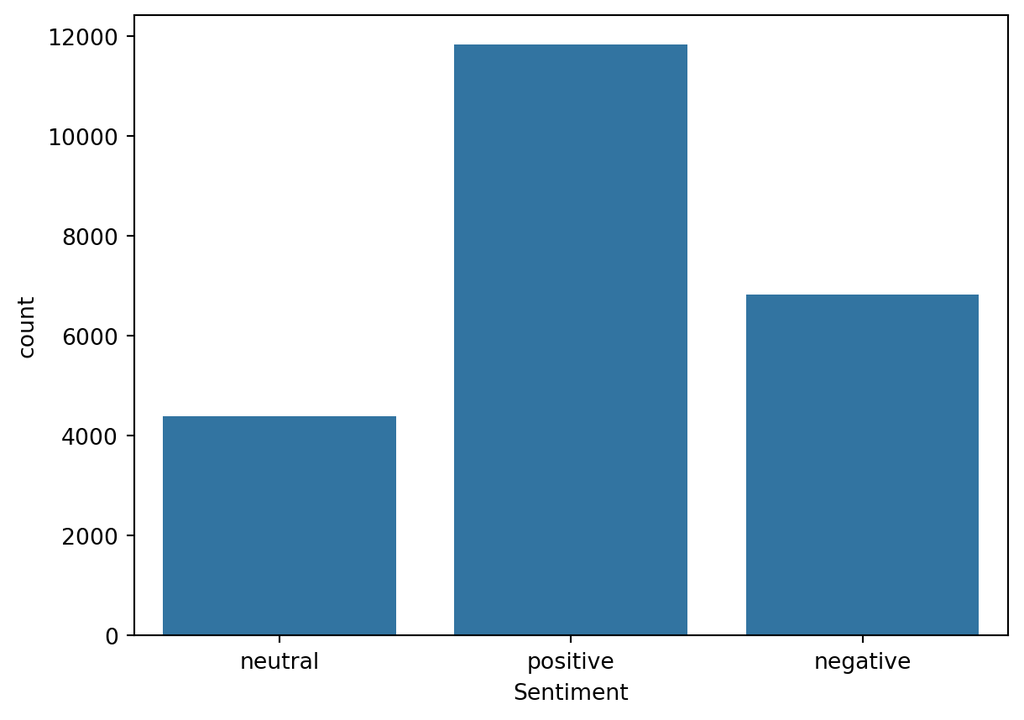

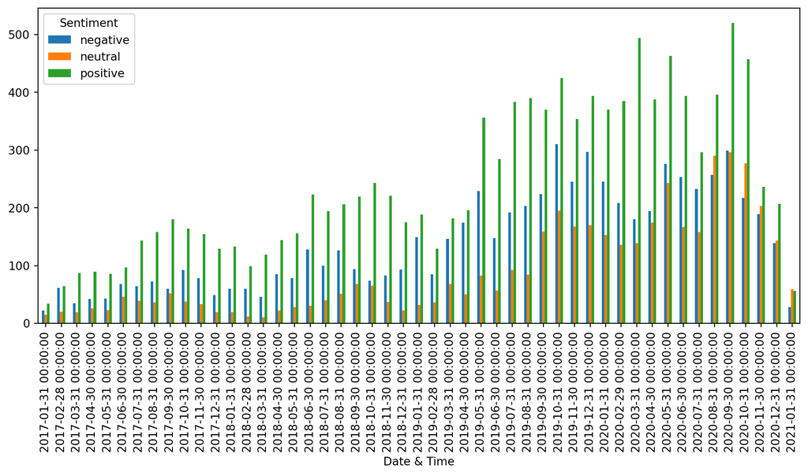

#### No anomalous correlations between target/response variable and features/explanatory variables validation

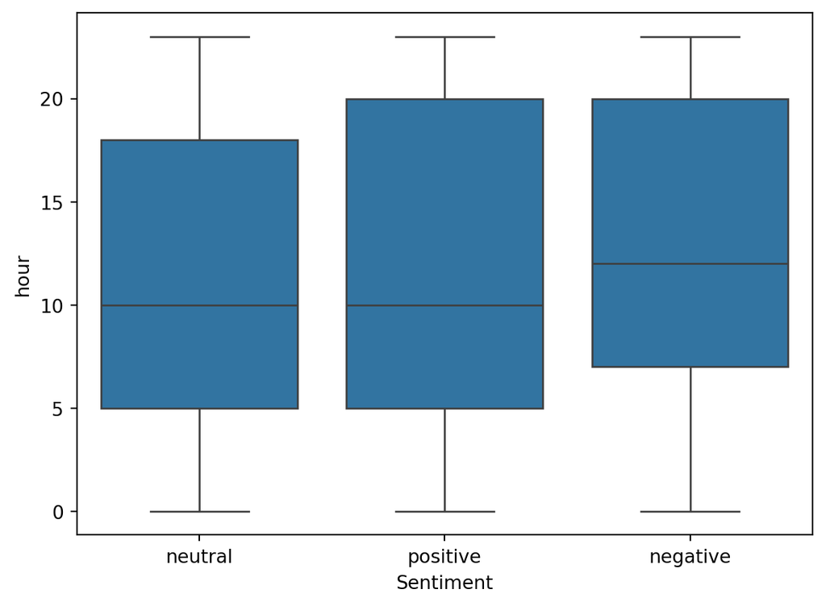

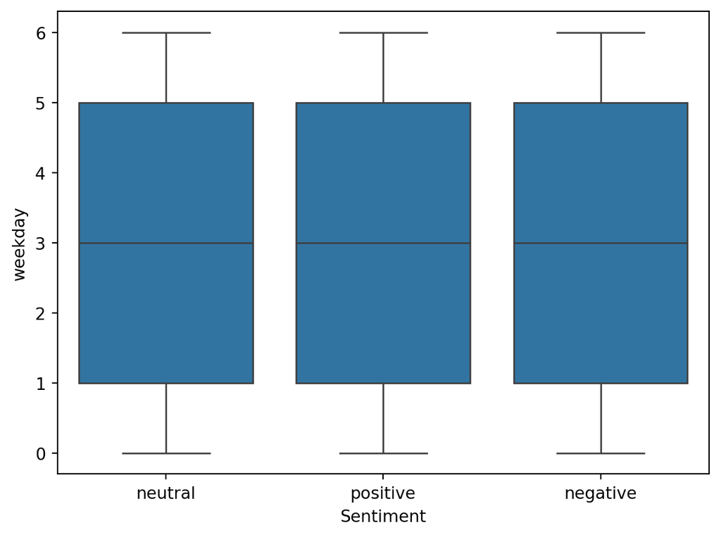

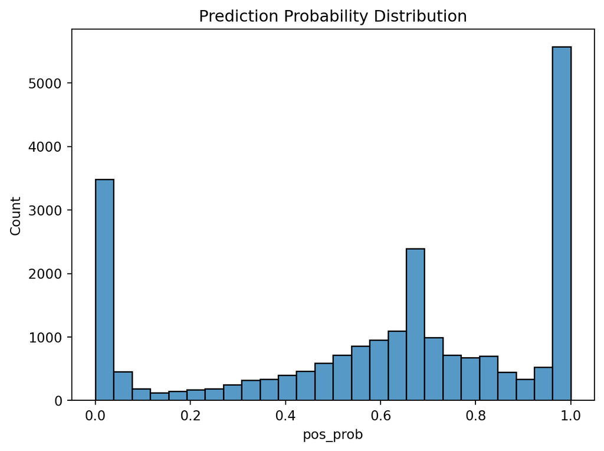

## Discussion

Within this report we considered multiple aspects of the tweets. Firstly we determined that Donald Trump’s most productive time and season for posting was Summer during the evening. Then we determined that, contrary to what we originally believed, most of his tweets are actually positively connotated. Now, as mentioned above, our sentiment classification methods might not be a faithful representations of the sentiment of the tweets, as there might be hidden meanings that the bag of words approach does not pick up on.

## References

Gottfried, Jeffrey, and Eugenie Park. 2025. “Americans’ Social Media Use. 2024.” *URL Https://Www. Pewresearch. Org/Internet/2024/01/31/Americans-Social-Media-Use/. Accessed*, 9–29.

McCarthy, Niall, and Felix Richter. 2021. “Infographic: End of the Road for Trump’s Twitter Account.” *Statista Daily Data*. https://www.statista.com/chart/19561/total-number-of-tweets-from-donald-trump/?srsltid=AfmBOorYyvrCIBJxWCwAxW5yYEl6cPXzdhu-oMfRfAPfoXrcdpIEA3fy.

Shear, Michael D, Maggie Haberman, Nicholas Confessore, Karen Yourish, Larry Buchanan, and Keith Collins. 2019. “How Trump Reshaped the Presidency in over 11,000 Tweets.” *International New York Times*, NA–.